# Basic Inferential Data Analysis Instructions

Jimmy

6/6/2020

### Statistical Inference Course Project

### Part 2 - Basic Inferential Data Analysis

**Description**

We’re going to analyze the ToothGrowth data in the R datasets package. The response is the length of odontoblasts (cells responsible for tooth growth) in 60 guinea pigs. Each animal received one of three dose levels of vitamin C (0.5, 1, and 2 mg/day) by one of two delivery methods, (orange juice or ascorbic acid (a form of vitamin C and coded as VC).

**1. Load the ToothGrowth data and perform some basic exploratory data analyses**

```r
data(ToothGrowth)
str(ToothGrowth)
```

```
## 'data.frame':    60 obs. of  3 variables:
##  $ len : num  4.2 11.5 7.3 5.8 6.4 10 11.2 11.2 5.2 7 ...
##  $ supp: Factor w/ 2 levels "OJ","VC": 2 2 2 2 2 2 2 2 2 2 ...
##  $ dose: num  0.5 0.5 0.5 0.5 0.5 0.5 0.5 0.5 0.5 0.5 ...
```

We can see that out data frame ToothGrowth contains 60 observation of 3 variables. Variable supp of type factor has two levels. VC stands for Vitamin C (ascorbic acid) and OJ is Orange Juice.

```r
table(ToothGrowth$supp, ToothGrowth$dose)
```

```
##
##      0.5  1  2
##   OJ  10 10 10
##   VC  10 10 10
```

We can see that for each supplement type we have 3 dose levels of vitamin C (0.5, 1, and 2 mg/day). Each supplement is tested on 30 guinea piggs and each supplement is tested in different doses on a subgroup of 10 guinea pigs.

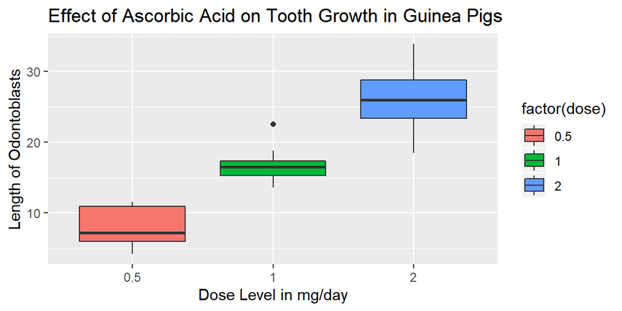

From the boxlots it’s obvious that the cells responsible for tooth growth in guinea pigs are getting longer as we increase the dose of ascorbic acid as a supplement.

```r
tapply(vitaminC$len, vitaminC$dose, mean)
```

```
##   0.5     1     2
##  7.98 16.77 26.14
```

```r
tapply(vitaminC$len, vitaminC$dose, var)
```

```
##       0.5         1         2
##  7.544000  6.326778 23.018222
```

We can see that both means and variances of each group differ noticeably.

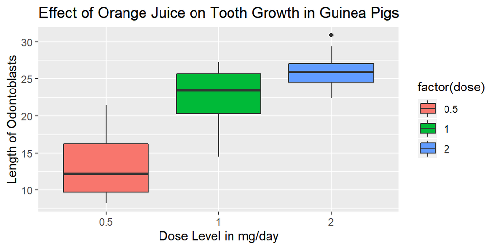

From these boxplots we can see that as the dose level increases, so does the lenght of odontoblasts.

```r
tapply(orangeJ$len, vitaminC$dose, mean)
```

```
##   0.5     1     2
## 13.23 22.70 26.06
```

```r
tapply(orangeJ$len, vitaminC$dose, var)
```

```
##       0.5         1         2
## 19.889000 15.295556  7.049333
```

We can also check if there is an overall difference in the effect on tooth growth between two supplements.

```r
tapply(ToothGrowth$len, ToothGrowth$supp, mean)
```

```
##       OJ       VC
## 20.66333 16.96333
```

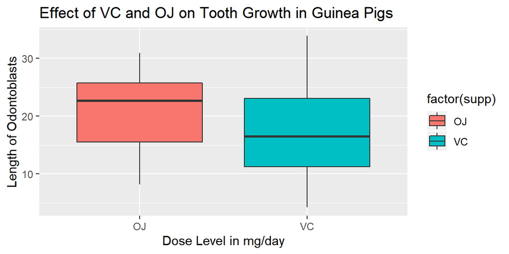

From this graph we can also see that acsorbic acid as a supplement has more varying effects on tooth growth in guinea pigs.

```r
tapply(ToothGrowth$len, ToothGrowth$supp, var)
```

```
##       OJ       VC
## 43.63344 68.32723
```

This confirms our initial claim that ascorbic acid causes greater variance in resulting length of odontoblasts (cells responsible for tooth growth). To see the overall effect of dose level on tooth growth:

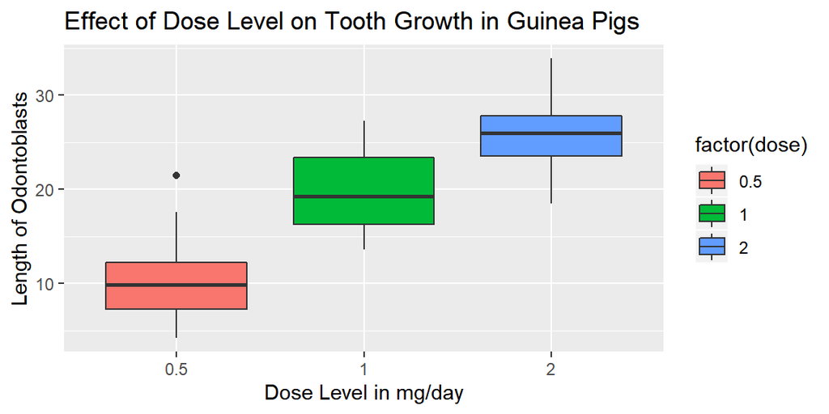

```r
tapply(ToothGrowth$len, ToothGrowth$dose, mean)
```

```
##    0.5      1      2
## 10.605 19.735 26.100
```

```r
tapply(ToothGrowth$len, ToothGrowth$dose, var)
```

```
##      0.5        1        2
## 20.24787 19.49608 14.24421
```

As expected, as we increase the dose, the lenght of odontoblasts increases irrelative of the supplement type used. **2. Provide a basic summary of the data.**

```r
summary(ToothGrowth)
```

```
##       len        supp         dose
##  Min.   : 4.20   OJ:30   Min.   :0.500
##  1st Qu.:13.07   VC:30   1st Qu.:0.500
##  Median :19.25           Median :1.000
##  Mean   :18.81           Mean   :1.167
##  3rd Qu.:25.27           3rd Qu.:2.000
##  Max.   :33.90           Max.   :2.000
```

From this output we can’t really see much, except that in each supplement subgroup there are 30 guinea pigs We also see that the overall mean of length of odontoblasts is 18.81 and the median is 19.25. Minimum length is 4.20 and maximum is 33.90. **3. Use confidence intervals and/or hypothesis tests to compare tooth growth by supp and dose.** (Only use the techniques from class, even if there’s other approaches worth considering) **First** we’ll test the alternative hypothesis that mean length of odontoblasts for ascorbic acid (VC) and orange juice (OJ) differs significantly. We’ll assume unequal variance and we know that these groups are not paired. Even though these setting are default in t.test(), I’ll assign them FALSE value for the sake of clarity.

```r
vitaminC <- subset(ToothGrowth, supp == 'VC')
orangeJ <- subset(ToothGrowth, supp == 'OJ')
t.test(vitaminC$len, orangeJ$len, paired = FALSE, var.equal = FALSE)
```

```
##
##  Welch Two Sample t-test
##
## data:  vitaminC$len and orangeJ$len
## t = -1.9153, df = 55.309, p-value = 0.06063
## alternative hypothesis: true difference in means is not equal to 0
## 95 percent confidence interval:
##  -7.5710156  0.1710156
## sample estimates:
## mean of x mean of y
##  16.96333  20.66333
```

As we can see p-value = 0.06063 > 0.05 => There is not enough evidence to reject the null hypothesis that the difference in average tooth length (odontoblasts) for VC and OJ group is equal to zero. In our **second step** we’ll do several t-tests to check if there’s a statistically significant difference in mean values of length of odontoblasts (tooth growth cells) between groups that were subjected to different dose levels of supplements. We’ll assume again that paired = FALSE and var.equal = FALSE, but since these are default in t.test() this time we’ll skip redundant assignments.

```r
dose05 <- ToothGrowth$len[ToothGrowth$dose == 0.5]
dose1 <- ToothGrowth$len[ToothGrowth$dose == 1.0]
dose2 <- ToothGrowth$len[ToothGrowth$dose == 2.0]
t.test(dose05, dose1 )
```

```
##
##  Welch Two Sample t-test
##
## data:  dose05 and dose1
## t = -6.4766, df = 37.986, p-value = 1.268e-07
## alternative hypothesis: true difference in means is not equal to 0
## 95 percent confidence interval:
##  -11.983781  -6.276219
## sample estimates:
## mean of x mean of y
##    10.605    19.735
```

```r
t.test(dose05, dose2)
```

```
##
##  Welch Two Sample t-test
##
## data:  dose05 and dose2
## t = -11.799, df = 36.883, p-value = 4.398e-14
## alternative hypothesis: true difference in means is not equal to 0
## 95 percent confidence interval:
##  -18.15617 -12.83383
## sample estimates:
## mean of x mean of y
##    10.605    26.100
```

```r
t.test(dose1, dose2)
```

```
##
##  Welch Two Sample t-test
##
## data:  dose1 and dose2
## t = -4.9005, df = 37.101, p-value = 1.906e-05
## alternative hypothesis: true difference in means is not equal to 0
## 95 percent confidence interval:
##  -8.996481 -3.733519
## sample estimates:
## mean of x mean of y
##    19.735    26.100
```

As we can see from all 3 t.tests p value is less than 0.05 and we can reject the null hypothesis that difference between means is equal to zero. We also see that all of the 95% confidence intervals are below zero which confirms are inital claims that the tooth growth increases as we increase the dose level. In the **third step** we’ll inspect the diference in mean lengths of odontoblasts (cells responsible for tooth growth) between ascorbic acid (VC) group and orange juice (OJ) group for each dose level applied.

```r
dose05VC <- vitaminC$len[vitaminC$dose == 0.5]
dose1VC <- vitaminC$len[vitaminC$dose == 1.0]
dose2VC <- vitaminC$len[vitaminC$dose == 2.0]
dose05OJ <- orangeJ$len[orangeJ$dose == 0.5]
dose1OJ <- orangeJ$len[orangeJ$dose == 1.0]
dose2OJ <- orangeJ$len[orangeJ$dose == 2.0]
```

As in previous cases, we’ll assume that observations are not paired and that variances are not equal.

```r
t.test(dose05VC, dose05OJ)
```

```
##
##  Welch Two Sample t-test
##
## data:  dose05VC and dose05OJ
## t = -3.1697, df = 14.969, p-value = 0.006359
## alternative hypothesis: true difference in means is not equal to 0
## 95 percent confidence interval:
##  -8.780943 -1.719057
## sample estimates:
## mean of x mean of y
##      7.98     13.23
```

```r
t.test(dose1VC, dose1OJ)
```

```
##
##  Welch Two Sample t-test
##
## data:  dose1VC and dose1OJ
## t = -4.0328, df = 15.358, p-value = 0.001038
## alternative hypothesis: true difference in means is not equal to 0
## 95 percent confidence interval:
##  -9.057852 -2.802148
## sample estimates:
## mean of x mean of y
##     16.77     22.70
```

```r
t.test(dose2VC, dose2OJ)
```

```
##
##  Welch Two Sample t-test
##
## data:  dose2VC and dose2OJ
## t = 0.046136, df = 14.04, p-value = 0.9639
## alternative hypothesis: true difference in means is not equal to 0
## 95 percent confidence interval:
##  -3.63807  3.79807
## sample estimates:
## mean of x mean of y
##     26.14     26.06
```

We can see from the t-tests that the difference between group means for VC and OJ is statistically significant for dose level 0.5 mg/day, where p = 0.006358 < p = 0.05 and for dose level of 1 mg/day, where the p value p = 0.001038 < p = 0.05. For dose level 2 mg/day we have that p-value = 0.9639 > = 0.05 and 95 percent confidence interval: -3.63807 3.79807 includes zero.We conclude that there is no statistically significant difference between the group means for VC and OJ when the dose level is 2 mg/day. **4. State your conclusions and the assumptions needed for your conclusions.** **Assumptions:** 1. Samples used are random iid samples. 2. Each sample is indeendent of one another, in other words, they are not paired. 3. The population distribution of each samle must be approximately normal or mound shaped and roughly symetric. **Conclusions:** 1. Supplement type alone does not affect the mean value of length of odontoblasts (cells responsible for toothgrowth). 2. Dose level alone, without consideraton of supplement type affects tooth growth significantly. Increasing the dosage will induce better tooth growth. 3. Orange Juice as a supplement, when used in dose levels of 0.5 mg/day and 1mg/day promotes better tooth growth than ascorbic acid. When applied in dose level of 2 mg/day, it has an effect on tooth growth similar to that of an ascorbic acid.